# Notes 3 - Exploratory Data Analysis

## Some other plotting notes

- The rgb function can be used to produce any color via red, green, blue proportions
- Color transparency can be added via the alpha parameter to rgb
- The colorspace package can be used for a different control over colors

Scatter plot with no transparency, an alternative to smoothScatter()

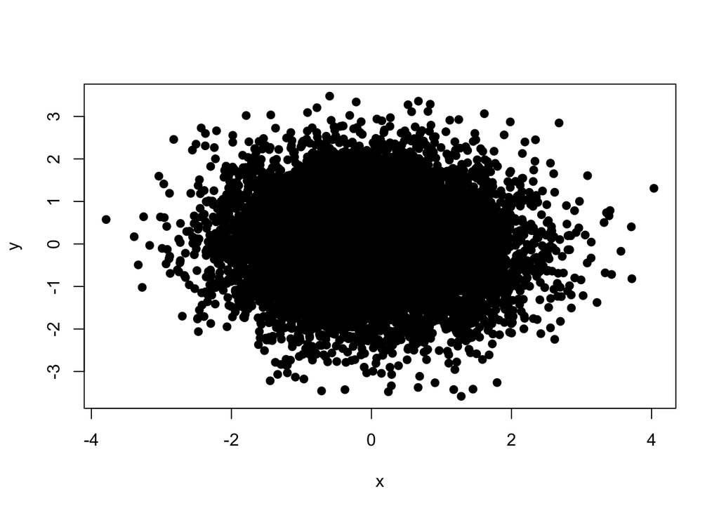

```r
plot(x, y, pch = 19)
```

Scatter plot with transparency

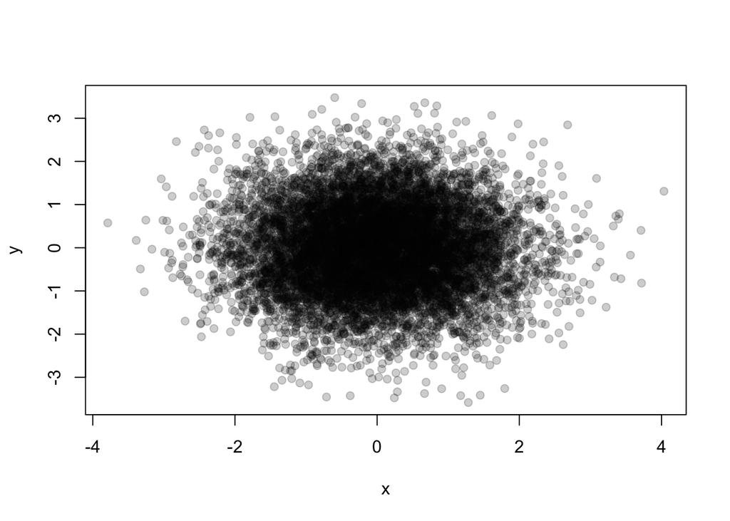

```r
plot(x, y, col = rgb(0, 0, 0, 0.2), pch = 19)
```

## Summary

- Careful use of colors in plots / maps / etc. can make it easier for the reader to get what you are tyring to say
- The RColorBrewer package provides color palettes for sequential, categorical, and diverging data
- The colorRamp and colorRampPalette functions can be used in conjunction with color palettes to connect data to colors
- Transparency can sometimes be used to clarify plots with many points